XML Schema Documentation

# XML Schema 1.0

XML schema for declaration input data according to EU Regulation 2017/2400 for component data and job data. *Note: has been updated a few times to take into account changes in the regulation*

## VectoInputDeclaration

*Namespace:* urn:tugraz:ivt:VectoAPI:DeclarationInput:v1.0

[figure not shown]

## VectoInputComponent

*Namespace:* urn:tugraz:ivt:VectoAPI:DeclarationComponent:v1.0

[figure not shown]

## VehicleDeclarationType

*Namespace:* urn:tugraz:ivt:VectoAPI:DeclarationDefinitions:v1.0

[figure not shown]

## VehicleComponentsType

*Namespace:* urn:tugraz:ivt:VectoAPI:DeclarationDefinitions:v1.0

[figure not shown]

## EngineDataDeclarationType

*Base Type:* v1.0:AbstractCombustionEngineDataDeclarationType*

[figure not shown]

## GearboxDataDeclarationType

*Namespace:* urn:tugraz:ivt:VectoAPI:DeclarationDefinitions:v1.0

*Base Type:* v1.0:AbstractTransmissionDataDeclarationType

[figure not shown]

*Namespace:* urn:tugraz:ivt:VectoAPI:DeclarationDefinitions:v1.0

*Base Type:* v1.0:GearBaseType

[figure not shown]

## TorqueConverterDataDeclarationType

*Namespace:* urn:tugraz:ivt:VectoAPI:DeclarationDefinitions:v1.0

*Base Type:* v1.0:AbstractTorqueConverterDataDeclarationType

[figure not shown]

## AngledriveDataDeclarationType

*Namespace:* urn:tugraz:ivt:VectoAPI:DeclarationDefinitions:v1.0

*Base Type:* v1.0:AbstractAngledriveDataDeclarationType*

[figure not shown]

## RetarderDataDeclarationType

*Namespace:* urn:tugraz:ivt:VectoAPI:DeclarationDefinitions:v1.0

*Base Type:* v1.0:AbstractRetarderDataDeclarationType

[figure not shown]

## AxlegearDataDeclarationType

*Namespace:* urn:tugraz:ivt:VectoAPI:DeclarationDefinitions:v1.0

*Base Type:* v1.0:AbstractAxlegearDataDeclarationType

[figure not shown]

## AxleWheelsDataDeclarationType

*Namespace:* urn:tugraz:ivt:VectoAPI:DeclarationDefinitions:v1.0

[figure not shown]

## AxleDeclarationType

*Namespace:* urn:tugraz:ivt:VectoAPI:DeclarationDefinitions:v1.0

[figure not shown]

## TyreDataDeclarationType

*Namespace:* urn:tugraz:ivt:VectoAPI:DeclarationDefinitions:v1.0

*Base Type:* v1.0:AbstractTyreDataDeclarationType

[figure not shown]

## AuxiliariesDataDeclarationType

*Namespace:* urn:tugraz:ivt:VectoAPI:DeclarationDefinitions:v1.0

*Base Type:* v1.0:AuxiliariesBaseType

[figure not shown]

## AirdragDataDeclarationType

*Namespace:* urn:tugraz:ivt:VectoAPI:DeclarationDefinitions:v1.0

*Base Type:* v1.0:AbstractAirdragDataDeclarationType

[figure not shown]

## SignatureType

*Namespace:* urn:tugraz:ivt:VectoAPI:DeclarationDefinitions:v1.0

[figure not shown]

# XML Schema 2.0

Updated and more flexible XML schema for VECTO declaration input. This schema allows to

- update the XML schema for single components
- use component data certified with XML schema 1.0
- use component data certified with XML schema 2.x

The XML structure for the vehicle data references abstract XML base types. Component data is derived from the abstreact base type and thus can be used whereever the abstract base type is required.

XML Schema 2.0 contains the same structure as schema version 1.0 before all updates applied to version 1.0, i.e., the input parameters *VocationalVehicle*, *SleeperCab*, *ZeroEmissionVehicle*, *ADAS*, *NgTankSystem* are not allowed.

## VectoInputDeclaration

*Namespace:* urn:tugraz:ivt:VectoAPI:DeclarationInput:v2.0

[figure not shown]

## VectoInputComponent

*Namespace:* urn:tugraz:ivt:VectoAPI:DeclarationComponent:v2.0

[figure not shown]

## VehicleDeclarationType

*Namespace:* urn:tugraz:ivt:VectoAPI:DeclarationDefinitions:v2.0

*Base Type:* v2.0:VehicleBaseType

*Base Type:* v2.0:AbstractVehicleDeclarationType

[figure not shown]

## PTOType

*Namespace:* urn:tugraz:ivt:VectoAPI:DeclarationDefinitions:v2.0

*Base Type:* v2.0:AbstractPTODataType

[figure not shown]

## VehicleComponentsType

*Namespace:* urn:tugraz:ivt:VectoAPI:DeclarationDefinitions:v2.0

[figure not shown]

## EngineDataDeclarationType

*Namespace:* urn:tugraz:ivt:VectoAPI:DeclarationDefinitions:v2.0

*Base Type:* v1.0:AbstractCombustionEngineDataDeclarationType

[figure not shown]

## GearboxDataDeclarationType

*Namespace:* urn:tugraz:ivt:VectoAPI:DeclarationDefinitions:v2.0

*Base Type:* v1.0:AbstractTransmissionDataDeclarationType

[figure not shown]

## GearsDeclarationType

*Namespace:* urn:tugraz:ivt:VectoAPI:DeclarationDefinitions:v2.0

*Base Type:* v2.0:AbstractGearsDeclarationType

[figure not shown]

## GearDeclarationType

*Namespace:* urn:tugraz:ivt:VectoAPI:DeclarationDefinitions:v2.0

*Base Type:* v2.0:GearBaseType

[figure not shown]

## TorqueConverterDataDeclarationType

*Namespace:* urn:tugraz:ivt:VectoAPI:DeclarationDefinitions:v2.0

*Base Type:* v1.0:AbstractTorqueConverterDataDeclarationType

[figure not shown]

## AngledriveDataDeclarationType

*Namespace:* urn:tugraz:ivt:VectoAPI:DeclarationDefinitions:v2.0

*Base Type:* v1.0:AbstractAngledriveDataDeclarationType

[figure not shown]

## RetarderDataDeclarationType

*Namespace:* urn:tugraz:ivt:VectoAPI:DeclarationDefinitions:v2.0

*Base Type:* v1.0:AbstractRetarderDataDeclarationType

[figure not shown]

## AxlegearDataDeclarationType

*Namespace:* urn:tugraz:ivt:VectoAPI:DeclarationDefinitions:v2.0

*Base Type:* v1.0:AbstractAxlegearDataDeclarationType

[figure not shown]

## AxleWheelsDataDeclarationType

*Namespace:* urn:tugraz:ivt:VectoAPI:DeclarationDefinitions:v2.0

*Base Type:* v2.0:AbstractAxleWheelsDataDeclarationType

[figure not shown]

## AxleDataDeclarationType

*Namespace:* urn:tugraz:ivt:VectoAPI:DeclarationDefinitions:v2.0

*Base Type:* v2.0:AbstractAxleDataDeclarationType

[figure not shown]

## TyreDataDeclarationType

*Namespace:* urn:tugraz:ivt:VectoAPI:DeclarationDefinitions:v2.0

*Base Type:* v1.0:AbstractTyreDataDeclarationType

[figure not shown]

## AuxiliariesDataDeclarationType

*Namespace:* urn:tugraz:ivt:VectoAPI:DeclarationDefinitions:v2.0

*Base Type:* v2.0:AbstractAuxiliariesDataDeclarationType

[figure not shown]

## AirdragDataDeclarationType

*Namespace:* urn:tugraz:ivt:VectoAPI:DeclarationDefinitions:v2.0

*Base Type:* v1.0:AbstractAirdragDataDeclarationType

[figure not shown]

## SignatureType

*Namespace:* urn:tugraz:ivt:VectoAPI:DeclarationDefinitions:v2.0

[figure not shown]

# XML Schema 2.1

Schema version 2.1 includes all changes introduced with the first amendment of EU Regulation 2017/2400. The following parameters are mandatory:

- ZeroEmissionVehicle
- VocationalVehicle
- SleeperCab
- NgTankSystem (only for vehicles with natural gas as fuel type)
- ADAS Parameters (advanced driver assistant system): Engine Stop/Start, EcoRoll without engine stop, EcoRoll with engine stop, Predictive CruiseControl

Introduction of a new Vehicle type: Exempted vehicles. No VECTO simulation is performed for such vehicles.

## VehicleDeclarationType

*Namespace:* urn:tugraz:ivt:VectoAPI:DeclarationDefinitions:v2.1

*Base Type:* v2.0:AbstractVehicleDeclarationType

[figure not shown]

## ExemptedVehicleDeclarationType

*Namespace:* urn:tugraz:ivt:VectoAPI:DeclarationDefinitions:v2.1

*Base Type:* v2.0:AbstractVehicleDeclarationType

[figure not shown]

## AdvancedDriverAssistantSystemsType

*Namespace:* urn:tugraz:ivt:VectoAPI:DeclarationDefinitions:v2.1

*Base Type:* v2.1:AbstractAdvancedDriverAssistantSystemsType

[figure not shown]

## EngineDataDeclarationType

*Namespace:* urn:tugraz:ivt:VectoAPI:DeclarationDefinitions:v2.1

*Base Type:* v1.0:AbstractCombustionEngineDataDeclarationType

[figure not shown]

# XML Schema 2.3 DEV

- Introduction of a new model parameter for ADAS in combination with AT transmisisons: ATEcoRollReleaseLockupClutch
- New Engine component data:
  - Adding model parameters for WHR systems: WHR Type, electrical and/or mechanical WHR Power
  - Adding support for dual fuel engines, adding support for dual mode engines
- New gearbox component data: adding parameter whether Differential (axlegear) is included in the loss-map (required for FWD vehicles)

## AdvancedDriverAssistantSystemsType

*Namespace:* urn:tugraz:ivt:VectoAPI:DeclarationDefinitions:DEV:v2.3

*Base Type:* v2.1:AbstractAdvancedDriverAssistantSystemsType

[figure not shown]

## EngineDataDeclarationType

*Namespace:* urn:tugraz:ivt:VectoAPI:DeclarationDefinitions:DEV:v2.3

*Base Type:* v1.0:AbstractCombustionEngineDataDeclarationType

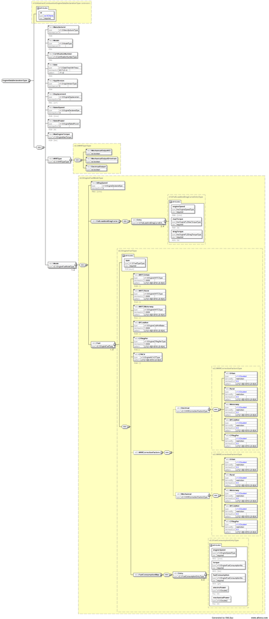

## TyreDataDeclarationType

*Namespace:* urn:tugraz:ivt:VectoAPI:DeclarationDefinitions:DEV:v2.3

*Base Type:* v1.0:AbstractTyreDataDeclarationType

[figure not shown]

# XML Schema 2.6 DEV

- New Vehicle type: Heavy Bus Primary Vehicle
- New Vehiclee type: Heavy Bus Completed Vehicle

## PrimaryVehicleDeclarationType

*Namespace:* urn:tugraz:ivt:VectoAPI:DeclarationDefinitions:DEV:v2.6

*Base Type:* v2.0:AbstractVehicleDeclarationType

[figure not shown]

## PrimaryVehicleComponentsDeclarationType

*Namespace:* urn:tugraz:ivt:VectoAPI:DeclarationDefinitions:DEV:v2.6

*Base Type:* v2.6:AbstractPrimaryVehicleComponentsDeclarationType

[figure not shown]

## PrimaryVehicleAuxiliaryDataDeclarationType

*Namespace:* urn:tugraz:ivt:VectoAPI:DeclarationDefinitions:DEV:v2.6

*Base Type:* v2.6:AbstractPrimaryVehicleAuxiliaryDataDeclarationType

[figure not shown]

## CompletedVehicleDeclarationType

*Namespace:* urn:tugraz:ivt:VectoAPI:DeclarationDefinitions:DEV:v2.6

*Base Type:* v2.0:AbstractVehicleDeclarationType

[figure not shown]

## CompletedVehicleComponentsDeclarationType

*Namespace:* urn:tugraz:ivt:VectoAPI:DeclarationDefinitions:DEV:v2.6

*Base Type:* v2.AbstractCompletedVehicleComponentsDeclarationType

[figure not shown]

## CompletedVehicleAuxiliaryDataDeclarationType

*Namespace:* urn:tugraz:ivt:VectoAPI:DeclarationDefinitions:DEV:v2.6

*Base Type:* v2.6:AbstractCompletedVehicleAuxiliaryDataDeclarationType

[figure not shown]

## VehicleMediumLorryDeclarationType

*Namespace:* urn:tugraz:ivt:VectoAPI:DeclarationDefinitions:DEV:v2.6

*Base Type:* v2.0:AbstractVehicleDeclarationType

[figure not shown]

## VehicleComponentsNoAxlegearType

*Namespace:* urn:tugraz:ivt:VectoAPI:DeclarationDefinitions:DEV:v2.6

*Base Type:* v2.0:AbstractVehicleComponentsDeclarationType

[figure not shown]

## GearboxDataDeclarationType

*Namespace:* urn:tugraz:ivt:VectoAPI:DeclarationDefinitions:DEV:v2.6

[figure not shown]